# Lab 5: Bikeshare SpaceTime Prediction

- Show All Code
- Hide All Code
- View Source

Rebalancing Indego in Philadelphia

Author

Wesley Nay

Published

April 21, 2026

# INTRODUCTION

## The Rebalancing Challenge in Philadelphia

Philadelphia’s Indego bike share system faces the same operational challenge as every bike share system: **rebalancing bikes to meet anticipated demand**.

In this report, I adapt the in-class Q1 2025 exercise to **Q3 2025** because I am interested in a seasonal comparison between winter and summer. Using station-hour panel data, weather data, census tract characteristics, and lagged demand measures, I build and compare several predictive models for bike share demand. I then examine where the model performs well, where it struggles, and whether prediction errors have operational or equity implications.

## Research Goals

This analysis addresses four main questions:

1. How do bike share demand patterns in **Q3 2025** differ from the in-class **Q1 2025** example?
2. Which model features improve predictive accuracy the most?
3. Where are prediction errors concentrated across space, time, and neighborhood context?
4. Can targeted feature engineering improve model performance in a meaningful way?

# SET UP

```r
library(tidyverse)
library(lubridate)
library(sf)
library(tigris)
library(tidycensus)
library(riem)  # For Philadelphia weather from ASOS stations

library(viridis) # color scales for visualization
library(knitr)
library(kableExtra)
library(patchwork)
library(scales)


library(here)
options(scipen = 999) # Get rid of scientific notation to make it look tidier
```

```r
plotTheme <- theme_minimal() +
  theme(
    plot.title    = element_text(size = 14, face = "bold"),
    plot.subtitle = element_text(size = 10),
    plot.caption  = element_text(size = 8),
    axis.text.x   = element_text(size = 10, angle = 45, hjust = 1),
    axis.text.y   = element_text(size = 10),
    axis.title    = element_text(size = 11, face = "bold"),
    panel.grid.major = element_line(colour = "#D0D0D0", linewidth = 0.2),
    panel.grid.minor = element_blank(),
    axis.ticks    = element_blank(),
    legend.position = "right"
  )

mapTheme <- theme_void() +
  theme(
    plot.title    = element_text(size = 14, face = "bold"),
    plot.subtitle = element_text(size = 10),
    plot.caption  = element_text(size = 8),
    legend.position  = "right",
    plot.margin      = margin(1, 1, 1, 1, "cm"),
    legend.key.height = unit(1, "cm"),
    legend.key.width  = unit(0.2, "cm")
  )

palette5 <- c("#eff3ff", "#bdd7e7", "#6baed6", "#3182bd", "#08519c")
```

```r
census_api_key(Sys.getenv("CENSUS_API_KEY"))
```

# IMPORT AND PREP DATA

## Load Indego Trip Data (Q3 2025)

```r
# Read Q3 2025 data
indego <- read.csv("data/indego-trips-2025-q3.csv")

# Quick look at the data
glimpse(indego)
```

```
Rows: 465,464
Columns: 15
$ trip_id             <int> 1203073573, 1203073759, 1203073753, 1203073877, 12…
$ duration            <int> 10, 19, 16, 19, 2, 6, 20, 4, 52, 3, 31, 9, 10, 9, …
$ start_time          <chr> "7/1/2025 0:06", "7/1/2025 0:11", "7/1/2025 0:13",…
$ end_time            <chr> "7/1/2025 0:16", "7/1/2025 0:30", "7/1/2025 0:29",…
$ start_station       <int> 3163, 3304, 3394, 3207, 3061, 3320, 3201, 3078, 32…
$ start_lat           <dbl> 39.94974, 39.94234, 39.92400, 39.95441, 39.95425, …
$ start_lon           <dbl> -75.18097, -75.15399, -75.16959, -75.19200, -75.17…
$ end_station         <int> 3374, 3315, 3394, 3368, 3156, 3320, 3196, 3235, 32…
$ end_lat             <dbl> 39.97280, 39.94235, 39.92400, 39.97647, 39.95381, …
$ end_lon             <dbl> -75.17971, -75.21138, -75.16959, -75.17362, -75.17…
$ bike_id             <chr> "31674", "29473", "27889", "31825", "25400", "3172…
$ plan_duration       <int> 30, 1, 30, 30, 30, 30, 30, 30, 30, 30, 30, 30, 30,…
$ trip_route_category <chr> "One Way", "One Way", "Round Trip", "One Way", "On…
$ passholder_type     <chr> "Indego30", "Walk-up", "Indego30", "Indego30", "In…
$ bike_type           <chr> "electric", "electric", "electric", "electric", "e…
```

After a quick examination of the data, I see that the geography provided is in latitude and longitude. This suggests that the coordinate system is probably in WGS84, which is a standard lat-long coordinate system for the entire world. Before conducting spatial analysis, I will have to project these coordinates into an appropriate CRS for Philadelphia.

The date and time structure of the data are currently stored as M/D/YY hour:minute (e.g., “7/1/2025 0:16”). These are character strings. This type of date and time structure might be difficult to work with later in the analysis, so I will have to adjust it into a proper datetime format using lubridate. Once parsed, I can create useful time variables for building the panel dataset that is necessary to work with bikeshare data like this.

## Examine the Data Structure

Basic Summary of Q3 2025 Indego Trip Data

| Metric | Value |
| --- | --- |
| Total trips | 465,464 |
| Unique start stations | 284 |
| Earliest trip | 2025-07-01 00:06:00 |
| Latest trip | 2025-09-30 23:58:00 |

In comparison to Q1 (January - March), Q3 (July - September) had much higher ridership. There were only 201,588 total trips in Q1. This is reasonable difference because Philadelphia experiences cold weather in the winter months of Q1, so people are less likely to want to ride bikes. Q3 is in the summer months, so the warmer weather can explain the higher total ridership. Additionally, it is probabaly more likely for tourists to visit Philadelphia in Q3 than in Q1, and tourism may also contribute to the higher ridership in Q3.

## Create Time Bins

Next, I need need to aggregate trips into hourly intervals for my panel data structure. I will use the lubridate library for the date/time data extraction.

```r
indego <- indego %>%
  mutate(
    start_datetime = mdy_hm(start_time),
    end_datetime = mdy_hm(end_time),
    interval60 = floor_date(start_datetime, unit = "hour"),
    week = week(interval60),
    month = month(interval60, label = TRUE, abbr = TRUE),
    dotw = wday(interval60, label = TRUE, abbr = TRUE),
    hour = hour(interval60),
    date = as.Date(interval60),
    weekend = ifelse(dotw %in% c("Sat", "Sun"), 1, 0),
    rush_hour = ifelse(hour %in% c(7, 8, 9, 16, 17, 18), 1, 0)
  )
```

The interval60 variable is the backbone of the panel structure. It rounds each trip down to the beginning of the hour, making it possible to aggregate all trips that started within the same hour at the same station. This is what allows the analysis to move from individual trips to station-level hourly demand.

# EXPLORATORY DATA ANALYSIS

## Trips Over Time

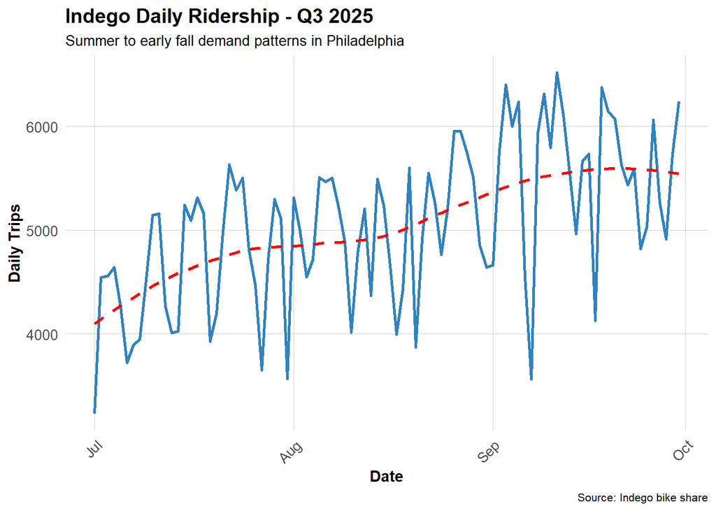

```r
# Daily trip counts
daily_trips <- indego %>%
  group_by(date) %>%
  summarize(trips = n(), .groups = "drop")

ggplot(daily_trips, aes(x = date, y = trips)) +
  geom_line(color = "#3182bd", linewidth = 1) +
  geom_smooth(se = FALSE, color = "red", linetype = "dashed") +
  labs(
    title = "Indego Daily Ridership - Q3 2025",
    subtitle = "Summer to early fall demand patterns in Philadelphia",
    x = "Date",
    y = "Daily Trips",
    caption = "Source: Indego bike share"
  ) +
  plotTheme
```

Ridership generally increases from the start of Q3 (July) through the end of September, but the slope is not gradual rather than steep. Ridership each month fluctuates, likely with increases during weekends. Weather may impact ridership as well during these summer months. There is one very steep dip September, which may be attributable to weather or some other limiting event. The fluctuations in ridership in Q3 are similar to what we saw in Q1, which likely reflects rider habits between weekdays and weekends.

## Holiday Checks

```r
holiday_comparison <- tibble(
  date = as.Date(c("2025-07-04", "2025-09-01")),
  holiday = c("Independence Day", "Labor Day")
) %>%
  left_join(daily_trips, by = "date") %>%
  mutate(
    comparison_group = c("Typical Friday", "Typical Monday"),
    comparison_avg = c(
      indego %>%
        filter(dotw == "Fri", date != as.Date("2025-07-04")) %>%
        group_by(date) %>%
        summarize(trips = n(), .groups = "drop") %>%
        summarize(avg_trips = mean(trips)) %>%
        pull(avg_trips),
      indego %>%
        filter(dotw == "Mon", date != as.Date("2025-09-01")) %>%
        group_by(date) %>%
        summarize(trips = n(), .groups = "drop") %>%
        summarize(avg_trips = mean(trips)) %>%
        pull(avg_trips)
    ),
    difference = trips - comparison_avg
  )

kable(
  holiday_comparison %>%
    mutate(
      trips = comma(round(trips)),
      comparison_avg = comma(round(comparison_avg)),
      difference = round(difference, 0)
    ),
  caption = "Holiday Ridership Compared to Typical Same-Day Ridership"
) %>%
  kable_styling(bootstrap_options = c("striped", "hover"))
```

Holiday Ridership Compared to Typical Same-Day Ridership

| date | holiday | trips | comparison_group | comparison_avg | difference |
| --- | --- | --- | --- | --- | --- |
| 2025-07-04 | Independence Day | 4,641 | Typical Friday | 5,544 | -903 |
| 2025-09-01 | Labor Day | 4,664 | Typical Monday | 4,962 | -298 |

I conducted a check of ridership on holidays like Independence Day and Labor Day to see how they impacted ridership. I thought that holidays might cause a spike in ridership, but the data did not reflect that. Both of these holidays had *lower* ridership than the average respective weekdays, as shown in the table printed above. This finding suggests that these summer holidays did not spike demand in Q3 as I initially expected.

## Hourly Patterns

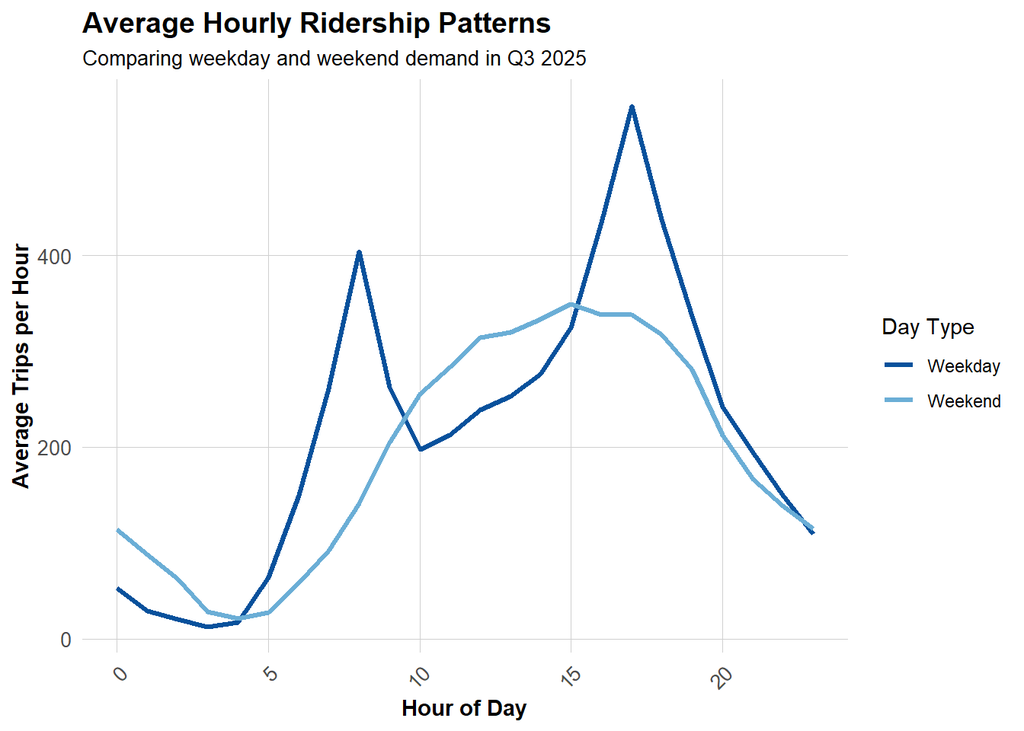

```r
# Average trips by hour and day type
hourly_patterns <- indego %>%
  group_by(hour, weekend) %>%
  summarize(avg_trips = n() / n_distinct(date), .groups = "drop") %>%
  mutate(day_type = ifelse(weekend == 1, "Weekend", "Weekday"))

ggplot(hourly_patterns, aes(x = hour, y = avg_trips, color = day_type)) +
  geom_line(linewidth = 1.2) +
  scale_color_manual(values = c("Weekday" = "#08519c", "Weekend" = "#6baed6")) +
  labs(
    title = "Average Hourly Ridership Patterns",
    subtitle = "Comparing weekday and weekend demand in Q3 2025",
    x = "Hour of Day",
    y = "Average Trips per Hour",
    color = "Day Type"
  ) +
  plotTheme
```

As seen above in the plot, weekdays actually have *higher* peaks than weekends in Q3. Ridership on weekdays peak in the morning around 8-9am and peak even higher in the evening around 5-6pm. This suggests that during the warm months of Q3, people are opting for Indego bikes as their form of commute to and from work.

Unlike weekdays, the weekends do not have sharp peaks in Q3. Instead, ridership is more spread out throughout the day, gradually increasing from the late morning and peaking in the afternoon around 12-5pm. This suggests that ridership on the weekends may be more leisurely as people ride during peak sunny hours.

While weekdays show a strong commuting pattern and weekends suggest leisurely rides, ridership for both weekdays and weekends taper off after about 6pm.

## Top Stations

```r
# Most popular origin stations
top_stations <- indego %>%
  count(start_station, start_lat, start_lon, name = "trips") %>%
  arrange(desc(trips)) %>%
  slice_head(n = 20)

kable(
  top_stations,
  caption = "Top 20 Indego Stations by Trip Origins",
  format.args = list(big.mark = ",")
) %>%
  kable_styling(bootstrap_options = c("striped", "hover"))
```

Top 20 Indego Stations by Trip Origins

| start_station | start_lat | start_lon | trips |
| --- | --- | --- | --- |
| 3,010 | 39.94711 | -75.16618 | 7,716 |
| 3,032 | 39.94527 | -75.17971 | 5,884 |
| 3,213 | 39.93887 | -75.16663 | 5,660 |
| 3,163 | 39.94974 | -75.18097 | 5,174 |
| 3,359 | 39.94888 | -75.16978 | 4,681 |
| 3,185 | 39.95169 | -75.15888 | 4,670 |
| 3,028 | 39.94061 | -75.14958 | 4,607 |
| 3,020 | 39.94855 | -75.19007 | 4,556 |
| 3,022 | 39.95472 | -75.18323 | 4,475 |
| 3,066 | 39.94561 | -75.17348 | 4,353 |
| 3,059 | 39.96244 | -75.16121 | 4,265 |
| 3,063 | 39.94633 | -75.16980 | 4,230 |
| 3,161 | 39.95486 | -75.18091 | 4,223 |
| 3,101 | 39.94295 | -75.15955 | 4,183 |
| 3,054 | 39.96250 | -75.17420 | 4,117 |
| 3,030 | 39.93935 | -75.15716 | 3,986 |
| 3,362 | 39.94816 | -75.16226 | 3,965 |
| 3,061 | 39.95425 | -75.17761 | 3,716 |
| 3,057 | 39.96439 | -75.17987 | 3,668 |
| 3,296 | 39.95134 | -75.16758 | 3,665 |

Above, I created a table to identify the busiest Indego stations to get a sense of where demand is the highest and if it is concentrated in any areas of Philadelphia. Because I only have the latitude and longitude right now, I cannot determine exactly what neighborhood or areas this demand is in.

So, I create a very simple map with the latitude and longitude coordinates including all the Indego stations in light grey and the busiest stations highlighted in blue circles.

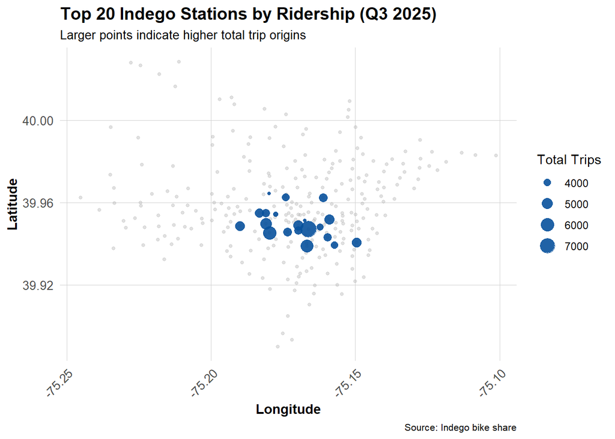

```r
ggplot() +
  geom_point(
    data = indego %>%
      distinct(start_station, start_lat, start_lon),
    aes(x = start_lon, y = start_lat),
    color = "grey70",
    size = 1,
    alpha = 0.4
  ) +

  # Top stations (highlighted)
  geom_point(
    data = top_stations,
    aes(x = start_lon, y = start_lat, size = trips),
    color = "#08519c",
    alpha = 0.9
  ) +

  scale_size_continuous(name = "Total Trips") +

  labs(
    title = "Top 20 Indego Stations by Ridership (Q3 2025)",
    subtitle = "Larger points indicate higher total trip origins",
    x = "Longitude",
    y = "Latitude",
    caption = "Source: Indego bike share"
  ) +

  plotTheme
```

From this simple lat/long map of the top 20 Indego stations, I can see that there is a clustering of demand for Indego bikes by where the trips begin. This area is likely close to employment centers because earlier in our data exploration, we saw that Q3 rides peak at commute hours. These stations may also be in higher density areas, which would explain the higher demand.

# PUT DATA IN CONTEXT

## Load Philadelphia Census Data

We’ll get census tract data to add demographic context to our stations.

```r
# Get Philadelphia census tracts
philly_census <- get_acs(
  geography = "tract",
  variables = c(
    "B01003_001",  # Total population
    "B19013_001",  # Median household income
    "B08301_001",  # Total commuters
    "B08301_010",  # Commute by transit
    "B02001_002",  # White alone
    "B25077_001"   # Median home value
  ),
  state = "PA",
  county = "Philadelphia",
  year = 2022,
  geometry = TRUE,
  output = "wide",
  progress_bar = FALSE
) %>%
  rename(
    Total_Pop = B01003_001E,
    Med_Inc = B19013_001E,
    Total_Commuters = B08301_001E,
    Transit_Commuters = B08301_010E,
    White_Pop = B02001_002E,
    Med_Home_Value = B25077_001E
  ) %>%
  mutate(
    Percent_Taking_Transit = (Transit_Commuters / Total_Commuters) * 100,
    Percent_White = (White_Pop / Total_Pop) * 100
  ) %>%
  st_transform(crs = 4326)  #transforming to WGS84 for lat/lon matching, currently in NAD83

# Check the data
glimpse(philly_census)
```

```
Rows: 408
Columns: 17
$ GEOID                  <chr> "42101001500", "42101001800", "42101002802", "4…
$ NAME                   <chr> "Census Tract 15; Philadelphia County; Pennsylv…
$ Total_Pop              <dbl> 3251, 3300, 5720, 4029, 4415, 1815, 3374, 2729,…
$ B01003_001M            <dbl> 677, 369, 796, 437, 853, 210, 480, 734, 763, 11…
$ Med_Inc                <dbl> 110859, 114063, 78871, 61583, 32347, 48581, 597…
$ B19013_001M            <dbl> 24975, 30714, 20396, 22293, 4840, 13812, 6278, …
$ Total_Commuters        <dbl> 2073, 2255, 3032, 2326, 1980, 969, 2427, 708, 2…
$ B08301_001M            <dbl> 387, 308, 478, 383, 456, 189, 380, 281, 456, 68…
$ Transit_Commuters      <dbl> 429, 123, 685, 506, 534, 192, 658, 218, 438, 51…
$ B08301_010M            <dbl> 188, 66, 219, 144, 285, 71, 278, 184, 176, 235,…
$ White_Pop              <dbl> 2185, 2494, 3691, 3223, 182, 984, 2111, 231, 35…
$ B02001_002M            <dbl> 268, 381, 592, 380, 88, 190, 463, 112, 238, 778…
$ Med_Home_Value         <dbl> 568300, 605000, 350600, 296400, 76600, 289700, …
$ B25077_001M            <dbl> 58894, 34876, 12572, 22333, 10843, 118720, 1506…
$ geometry               <MULTIPOLYGON [°]> MULTIPOLYGON (((-75.16558 3..., MU…
$ Percent_Taking_Transit <dbl> 20.694645, 5.454545, 22.592348, 21.754084, 26.9…
$ Percent_White          <dbl> 67.2100892, 75.5757576, 64.5279720, 79.9950360,…
```

I gather census data here because these variables help contextualize demand by capturing broader structural conditions that *may* influence travel behavior.

## Map Philadelphia Context

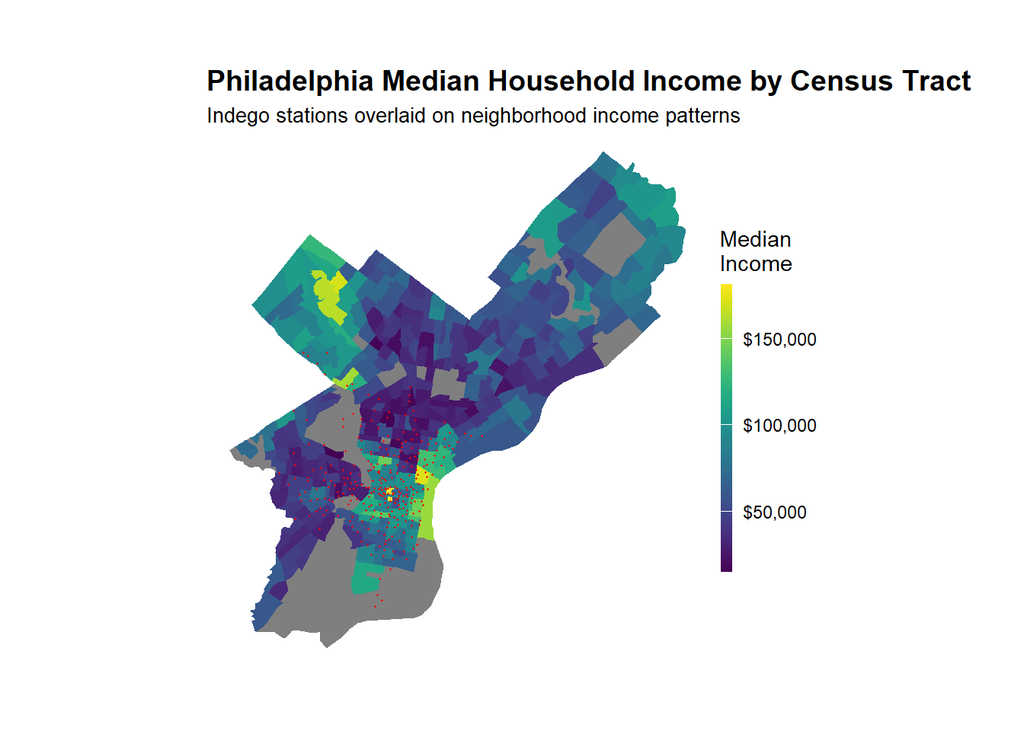

```r
# Map median income
ggplot() +
  geom_sf(data = philly_census, aes(fill = Med_Inc), color = NA) +
  scale_fill_viridis(
    option = "viridis",
    name = "Median\nIncome",
    labels = dollar
  ) +
  geom_point(
    data = indego,
    aes(x = start_lon, y = start_lat),
    color = "red",
    size = 0.25,
    alpha = 0.6
  ) +
  labs(
    title = "Philadelphia Median Household Income by Census Tract",
    subtitle = "Indego stations overlaid on neighborhood income patterns"
  ) +
  mapTheme
```

As seen in the map above, Indego stations are heavily concentrated in and around Center City. This suggests that bike share usage is closely tied to dense, central parts of the city where there is a mix of residential, commercial, and transit activity. There does not seem to be an apparent relationship to the location of Indego stations with median income, which further suggests that density and activity are more related to placement of these Indego stations. The clustering of stations in these areas indicates that demand is not evenly distributed across Philadelphia, but instead focused in neighborhoods with higher levels of daily activity.

## Join Census Data to Stations

We’ll spatially join census characteristics to each bike station.

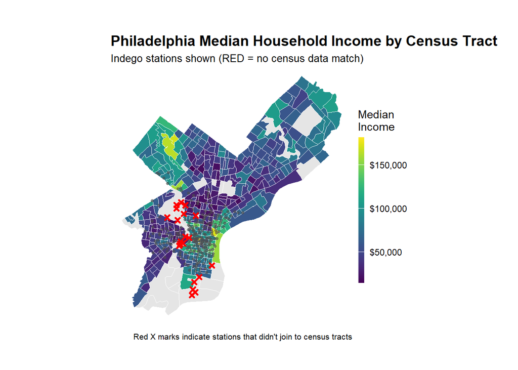

```r
# Create sf object for stations
stations_sf <- indego %>%
  distinct(start_station, start_lat, start_lon) %>%
  filter(!is.na(start_lat), !is.na(start_lon)) %>%
  st_as_sf(coords = c("start_lon", "start_lat"), crs = 4326)

# Spatial join to get census tract for each station
stations_census <- st_join(stations_sf, philly_census, left = TRUE) %>%
  st_drop_geometry()

# Look at the result - investigate whether all of the stations joined to census data -- according to the map above there are stations in non-residential tracts.

stations_for_map <- indego %>%
  distinct(start_station, start_lat, start_lon) %>%
  filter(!is.na(start_lat), !is.na(start_lon)) %>%
  left_join(
    stations_census %>% select(start_station, Med_Inc),
    by = "start_station"
  ) %>%
  mutate(has_census = !is.na(Med_Inc))

# Add back to trip data
indego_census <- indego %>%
  left_join(
    stations_census %>%
      select(start_station, Med_Inc, Percent_Taking_Transit,
             Percent_White, Total_Pop),
    by = "start_station"
  )

# Prepare data for visualization
stations_for_map <- indego %>%
  distinct(start_station, start_lat, start_lon) %>%
  filter(!is.na(start_lat), !is.na(start_lon)) %>%
  left_join(
    stations_census %>% select(start_station, Med_Inc),
    by = "start_station"
  ) %>%
  mutate(has_census = !is.na(Med_Inc))

# Create the map showing problem stations
ggplot() +
  geom_sf(data = philly_census, aes(fill = Med_Inc), color = "white", size = 0.1) +
  scale_fill_viridis(
    option = "viridis",
    name = "Median\nIncome",
    labels = scales::dollar,
    na.value = "grey90"
  ) +
  # Stations with census data (small grey dots)
  geom_point(
    data = stations_for_map %>% filter(has_census),
    aes(x = start_lon, y = start_lat),
    color = "grey30", size = 1, alpha = 0.6
  ) +
  # Stations WITHOUT census data (red X marks the spot)
  geom_point(
    data = stations_for_map %>% filter(!has_census),
    aes(x = start_lon, y = start_lat),
    color = "red", size = 1, shape = 4, stroke = 1.5
  ) +
  labs(
    title = "Philadelphia Median Household Income by Census Tract",
    subtitle = "Indego stations shown (RED = no census data match)",
    caption = "Red X marks indicate stations that didn't join to census tracts"
  ) +
  mapTheme
```

The map above show us where Indego stations don’t match up with a census tract. This is likely because some stations are located in non-residential areas, such as parks, along the waterfront, or near major infrastructure, where they do not fall within a defined census tract.

This creates an issue for our analysis, since these stations cannot be linked to neighborhood-level demographic data.

## Dealing with missing data

There are a few ways we can deal with these non-residential bike-share stations. In this analysis, I will remove them to keep things simple and to focus only on stations in residential neighborhoods.

```r
# Identify which stations to keep
valid_stations <- stations_census %>%
  filter(!is.na(Med_Inc)) %>%
  pull(start_station)

# Filter trip data to valid stations only
indego_census <- indego %>%
  filter(start_station %in% valid_stations) %>%
  left_join(
    stations_census %>%
      select(start_station, Med_Inc, Percent_Taking_Transit,
             Percent_White, Total_Pop),
    by = "start_station"
  )
```

## Get Weather Data

Weather significantly affects bike share demand! Let’s get hourly weather for Philadelphia.

```r
# Get weather from Philadelphia International Airport (KPHL)
weather_data <- riem_measures(
  station = "PHL",
  date_start = "2025-07-01",
  date_end = "2025-09-30"
)

weather_processed <- weather_data %>%
  mutate(
    interval60 = floor_date(valid, unit = "hour"),
    Temperature = tmpf,
    Precipitation = ifelse(is.na(p01i), 0, p01i),
    Wind_Speed = sknt
  ) %>%
  select(interval60, Temperature, Precipitation, Wind_Speed) %>%
  distinct(interval60, .keep_all = TRUE)

weather_complete <- weather_processed %>%
  complete(interval60 = seq(min(interval60), max(interval60), by = "hour")) %>%
  fill(Temperature, Precipitation, Wind_Speed, .direction = "down")

# Process weather data
weather_processed <- weather_data %>%
  mutate(
    interval60 = floor_date(valid, unit = "hour"),
    Temperature = tmpf,  # Temperature in Fahrenheit
    Precipitation = ifelse(is.na(p01i), 0, p01i),  # Hourly precip in inches
    Wind_Speed = sknt  # Wind speed in knots
  ) %>%
  select(interval60, Temperature, Precipitation, Wind_Speed) %>%
  distinct(interval60, .keep_all = TRUE)

# Check for missing hours and interpolate if needed
weather_complete <- weather_processed %>%
  complete(interval60 = seq(min(interval60), max(interval60), by = "hour")) %>%
  fill(Temperature, Precipitation, Wind_Speed, .direction = "down")

# Look at the weather
summary(weather_complete %>% select(Temperature, Precipitation, Wind_Speed))
```

```
  Temperature    Precipitation         Wind_Speed
 Min.   :57.00   Min.   :0.0000000   Min.   : 0.000
 1st Qu.:70.00   1st Qu.:0.0000000   1st Qu.: 4.000
 Median :76.00   Median :0.0000000   Median : 6.000
 Mean   :75.94   Mean   :0.0008342   Mean   : 6.218
 3rd Qu.:81.00   3rd Qu.:0.0000000   3rd Qu.: 8.000
 Max.   :98.00   Max.   :0.1000000   Max.   :25.000
```

## Visualize Weather Patterns

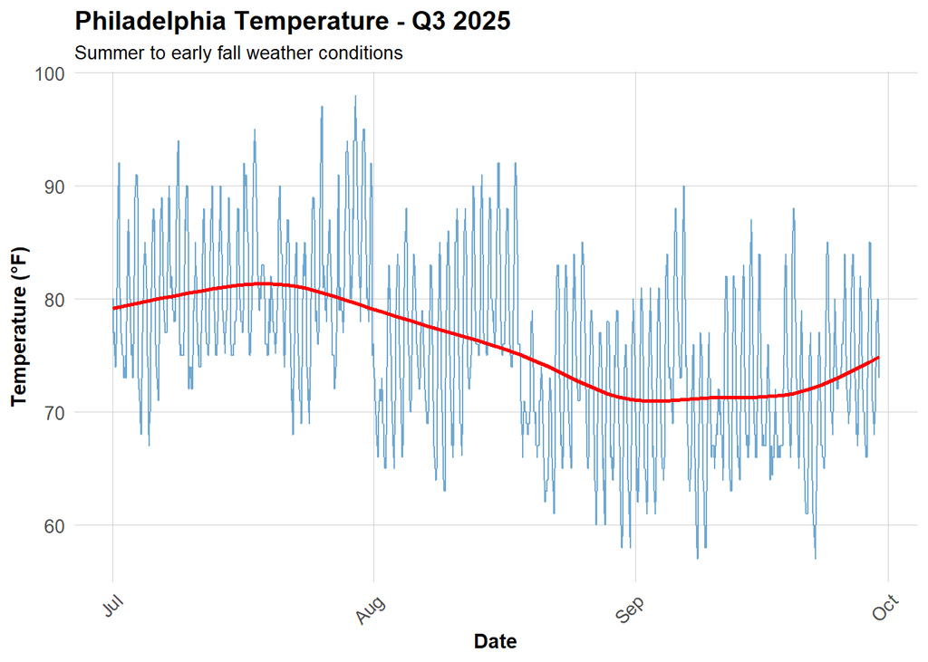

```r
ggplot(weather_complete, aes(x = interval60, y = Temperature)) +
  geom_line(color = "#3182bd", alpha = 0.7) +
  geom_smooth(se = FALSE, color = "red") +
  labs(
    title = "Philadelphia Temperature - Q3 2025",
    subtitle = "Summer to early fall weather conditions",
    x = "Date",
    y = "Temperature (°F)"
  ) +
  plotTheme
```

For most of July and August, conditions are consistently warm, which likely supports higher ridership, although the hottest days could also make biking less appealing. By September, temperatures are a bit cooler and probably more comfortable overall, which could help sustain ridership even as summer ends.

# CREATE SPACE-TIME PANEL

## Aggregate Trips to Station-Hour Level

```r
trips_panel <- indego_census %>%
  group_by(
    interval60, start_station, start_lat, start_lon,
    Med_Inc, Percent_Taking_Transit, Percent_White, Total_Pop
  ) %>%
  summarize(Trip_Count = n(), .groups = "drop")
```

## Create Complete Panel Structure

Not every station has trips every hour. We need a **complete panel** where every station-hour combination exists (even if Trip_Count = 0).

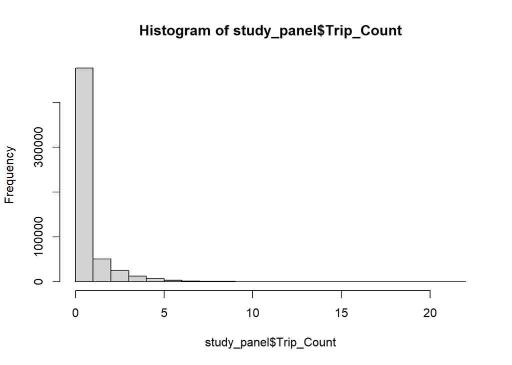

```r
# Calculate expected panel size
n_stations <- length(unique(trips_panel$start_station))
n_hours <- length(unique(trips_panel$interval60))
expected_rows <- n_stations * n_hours

# Create complete panel
study_panel <- expand_grid(
  interval60 = unique(trips_panel$interval60),
  start_station = unique(trips_panel$start_station)
) %>%
  # Join trip counts
  left_join(trips_panel %>%
              select(interval60, start_station, Trip_Count),
            by = c("interval60", "start_station")) %>%
  # Replace NA trip counts with 0
  mutate(Trip_Count = replace_na(Trip_Count, 0))

hist(study_panel$Trip_Count)
```

```r
# Fill in station attributes (they're the same for all hours)
station_attributes <- trips_panel %>%
  group_by(start_station) %>%
  summarize(
    start_lat = first(start_lat),
    start_lon = first(start_lon),
    Med_Inc = first(Med_Inc),
    Percent_Taking_Transit = first(Percent_Taking_Transit),
    Percent_White = first(Percent_White),
    Total_Pop = first(Total_Pop)
  )

study_panel <- study_panel %>%
  left_join(station_attributes, by = "start_station")
```

In examining the histogram of trip count, we see that most of the observations are clustered at very low trip counts, with a large share of station-hours having 0 or 1 trips. The distribution is heavily right-skewed, with a long tail of higher values but relatively few instances where trip counts get above 5 or 10.

This suggests that while there are occasional periods of higher demand, most station-hours experience very low activity. In other words, high ridership is relatively rare and concentrated in specific times and places rather than being the norm across the system.

## Add Time Features

```r
study_panel <- study_panel %>%
  mutate(
    week = week(interval60),
    month = month(interval60, label = TRUE),
    dotw = wday(interval60, label = TRUE),
    hour = hour(interval60),
    date = as.Date(interval60),
    weekend = ifelse(dotw %in% c("Sat", "Sun"), 1, 0),
    rush_hour = ifelse(hour %in% c(7, 8, 9, 16, 17, 18), 1, 0)
  )
```

## Join Weather Data

```r
study_panel <- study_panel %>%
  left_join(weather_complete, by = "interval60")

# Check for missing values
summary(study_panel %>% select(Trip_Count, Temperature, Precipitation))
```

```
   Trip_Count       Temperature    Precipitation
 Min.   : 0.0000   Min.   :57.00   Min.   :0.0000
 1st Qu.: 0.0000   1st Qu.:70.00   1st Qu.:0.0000
 Median : 0.0000   Median :76.00   Median :0.0000
 Mean   : 0.7548   Mean   :75.94   Mean   :0.0008
 3rd Qu.: 1.0000   3rd Qu.:81.00   3rd Qu.:0.0000
 Max.   :22.0000   Max.   :98.00   Max.   :0.1000
                   NA's   :6312    NA's   :6312
```

# CREATE TEMPORAL LAG VARIABLES

The key innovation for space-time prediction: **past demand predicts future demand**.

## Why Temporal Lags?

Temporal lags are especially important in a bikeshare context because demand is often persistent. If a station had high demand one hour ago, it is more likely to have elevated demand now than a station with no recent activity. In other words, temporal dependence helps the model capture short-run demand momentum.

```r
# Sort by station and time
study_panel <- study_panel %>%
  arrange(start_station, interval60)

# Create lag variables WITHIN each station
study_panel <- study_panel %>%
  group_by(start_station) %>%
  mutate(
    lag1Hour = lag(Trip_Count, 1),
    lag2Hours = lag(Trip_Count, 2),
    lag3Hours = lag(Trip_Count, 3),
    lag12Hours = lag(Trip_Count, 12),
    lag1day = lag(Trip_Count, 24)
  ) %>%
  ungroup()

# Remove rows with NA lags (first 24 hours for each station)
study_panel_complete <- study_panel %>%
  filter(!is.na(lag1day))
```

## Visualize Lag Correlations

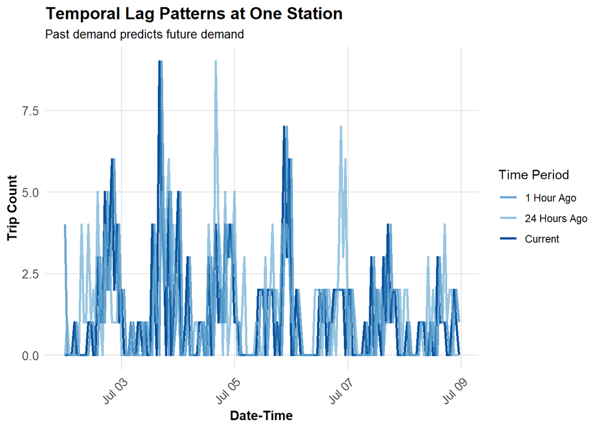

```r
# Sample one station to visualize
example_station <- study_panel_complete %>%
  filter(start_station == first(start_station)) %>%
  head(168)  # One week

# Plot actual vs lagged demand
ggplot(example_station, aes(x = interval60)) +
  geom_line(aes(y = Trip_Count, color = "Current"), linewidth = 1) +
  geom_line(aes(y = lag1Hour, color = "1 Hour Ago"), linewidth = 1, alpha = 0.7) +
  geom_line(aes(y = lag1day, color = "24 Hours Ago"), linewidth = 1, alpha = 0.7) +
  scale_color_manual(values = c(
    "Current" = "#08519c",
    "1 Hour Ago" = "#3182bd",
    "24 Hours Ago" = "#6baed6"
  )) +
  labs(
    title = "Temporal Lag Patterns at One Station",
    subtitle = "Past demand predicts future demand",
    x = "Date-Time",
    y = "Trip Count",
    color = "Time Period"
  ) +
  plotTheme
```

# TEMPORAL TRAIN/TEST SPLIT

**CRITICAL:** We must train on PAST data and test on FUTURE data!

## Why Temporal Validation Matters

In real operations, at the start of September, we would need to predict demand for the rest of the month using only the data available from July and August. We wouldn’t have access to future data because it hasn’t happened yet.

Wrong approach: Train the model on later weeks (e.g., late September) and test it on earlier weeks (e.g., July and August). This would mean using future information to predict the past.

```r
# Split by week
# Q3 has roughly weeks 27-40 (July-Sep)
# Train on weeks 27-38 (July through most of September)
# Test on weeks 39-40 (late September)

# Which stations have trips in BOTH early and late periods?
early_stations <- study_panel_complete %>%
  filter(week < 39) %>%
  filter(Trip_Count > 0) %>%
  distinct(start_station) %>%
  pull(start_station)

late_stations <- study_panel_complete %>%
  filter(week >= 39) %>%
  filter(Trip_Count > 0) %>%
  distinct(start_station) %>%
  pull(start_station)

# Keep only stations that appear in BOTH periods
common_stations <- intersect(early_stations, late_stations)

# Filter panel to only common stations
study_panel_complete <- study_panel_complete %>%
  filter(start_station %in% common_stations)

# NOW create train/test split
train <- study_panel_complete %>%
  filter(week < 39)

test <- study_panel_complete %>%
  filter(week >= 39)

# table summary
split_summary <- tibble(
  Dataset = c("Training", "Testing"),
  Observations = c(nrow(train), nrow(test)),
  Start_Date = c(min(train$date), min(test$date)),
  End_Date = c(max(train$date), max(test$date))
)

kable(
  split_summary %>%
    mutate(Observations = format(Observations, big.mark = ",")),
  caption = "Train/Test Split Summary (Q3 2025)"
) %>%
  kable_styling(bootstrap_options = c("striped", "hover"))
```

Train/Test Split Summary (Q3 2025)

| Dataset | Observations | Start_Date | End_Date |
| --- | --- | --- | --- |
| Training | 528,192 | 2025-07-02 | 2025-09-23 |
| Testing | 44,016 | 2025-09-24 | 2025-09-30 |

Q3 2025 spans roughly calendar weeks 27 through 40, so I use the earlier weeks of the quarter as training data and the last part of the quarter as the test set. This preserves the temporal order of the data and better reflects how the model would be used in practice.

I will build 5 models with increasing complexity to see what improves predictions.

## Prepare Factors

```r
train <- train %>%
  mutate(
    dotw_simple = factor(dotw, levels = c("Mon", "Tue", "Wed", "Thu", "Fri", "Sat", "Sun"))
  )

test <- test %>%
  mutate(
    dotw_simple = factor(dotw, levels = c("Mon", "Tue", "Wed", "Thu", "Fri", "Sat", "Sun"))
  )

contrasts(train$dotw_simple) <- contr.treatment(7)
contrasts(test$dotw_simple) <- contr.treatment(7)
```

## Model 1: Baseline (Time + Weather)

```r
# run model 1
model1 <- lm(
  Trip_Count ~ as.factor(hour) + dotw_simple + Temperature + Precipitation,
  data = train
)

summary(model1)
```

```
Call:
lm(formula = Trip_Count ~ as.factor(hour) + dotw_simple + Temperature +
    Precipitation, data = train)

Residuals:
    Min      1Q  Median      3Q     Max
-1.8922 -0.7975 -0.2197  0.2015 21.0499

Coefficients:
                    Estimate Std. Error t value             Pr(>|t|)
(Intercept)        0.7072478  0.0247665  28.557 < 0.0000000000000002 ***
as.factor(hour)1  -0.0963726  0.0123811  -7.784  0.00000000000000705 ***
as.factor(hour)2  -0.1596025  0.0123976 -12.874 < 0.0000000000000002 ***
as.factor(hour)3  -0.2241950  0.0124218 -18.049 < 0.0000000000000002 ***
as.factor(hour)4  -0.2275441  0.0124534 -18.272 < 0.0000000000000002 ***
as.factor(hour)5  -0.0950449  0.0124658  -7.624  0.00000000000002454 ***
as.factor(hour)6   0.1526526  0.0125000  12.212 < 0.0000000000000002 ***
as.factor(hour)7   0.4585458  0.0125158  36.637 < 0.0000000000000002 ***
as.factor(hour)8   0.8926632  0.0125470  71.145 < 0.0000000000000002 ***
as.factor(hour)9   0.5910232  0.0125523  47.085 < 0.0000000000000002 ***
as.factor(hour)10  0.4683100  0.0125475  37.323 < 0.0000000000000002 ***
as.factor(hour)11  0.5403187  0.0124707  43.327 < 0.0000000000000002 ***
as.factor(hour)12  0.6440333  0.0124022  51.929 < 0.0000000000000002 ***
as.factor(hour)13  0.7048107  0.0123715  56.970 < 0.0000000000000002 ***
as.factor(hour)14  0.7884382  0.0123810  63.681 < 0.0000000000000002 ***
as.factor(hour)15  0.9213292  0.0124195  74.184 < 0.0000000000000002 ***
as.factor(hour)16  1.1636206  0.0124701  93.313 < 0.0000000000000002 ***
as.factor(hour)17  1.5034643  0.0125182 120.102 < 0.0000000000000002 ***
as.factor(hour)18  1.2121796  0.0125547  96.552 < 0.0000000000000002 ***
as.factor(hour)19  0.9377406  0.0125567  74.681 < 0.0000000000000002 ***
as.factor(hour)20  0.6323085  0.0125482  50.390 < 0.0000000000000002 ***
as.factor(hour)21  0.4407280  0.0124882  35.292 < 0.0000000000000002 ***
as.factor(hour)22  0.2952485  0.0124342  23.745 < 0.0000000000000002 ***
as.factor(hour)23  0.1550244  0.0123841  12.518 < 0.0000000000000002 ***
dotw_simple2       0.0918069  0.0066781  13.748 < 0.0000000000000002 ***
dotw_simple3       0.0272366  0.0066792   4.078  0.00004546819774286 ***
dotw_simple4       0.0880320  0.0066994  13.140 < 0.0000000000000002 ***
dotw_simple5       0.0879719  0.0066822  13.165 < 0.0000000000000002 ***
dotw_simple6       0.0009803  0.0066793   0.147                0.883
dotw_simple7      -0.0753999  0.0066821 -11.284 < 0.0000000000000002 ***
Temperature       -0.0061593  0.0002982 -20.657 < 0.0000000000000002 ***
Precipitation     -4.8641943  0.3652546 -13.317 < 0.0000000000000002 ***
---
Signif. codes:  0 '***' 0.001 '**' 0.01 '*' 0.05 '.' 0.1 ' ' 1

Residual standard error: 1.297 on 528160 degrees of freedom
Multiple R-squared:  0.1139,    Adjusted R-squared:  0.1139
F-statistic:  2191 on 31 and 528160 DF,  p-value: < 0.00000000000000022
```

The model uses Monday as the baseline. Each coefficient represents the difference in expected trips per station-hour compared to Monday - dow_simple2 = Tuesday. Model 1 establishes a baseline using only temporal structure and weather. This is a useful starting point because even without station-level history or neighborhood context, bike demand should still vary systematically by hour, weekday/weekend rhythms, and weather conditions. In Q3, temperature may not have the same simple positive relationship with ridership that it might have in colder months, since extreme heat can also suppress demand.

**Weekday Pattern (Tue-Fri):**

- Most weekdays have positive coefficients, indicating slightly higher ridership compared to Monday (the baseline)
- Tuesday shows the largest increase (+0.092), followed by Thursday and Friday (both around +0.088)
- Wednesday is positive but smaller (+0.027), suggesting a more moderate increase
- Overall, weekdays tend to have slightly higher ridership than Monday, likely reflecting consistent commuting patterns during the workweek

**Weekend Pattern (Sat-Sun):**

- Saturday has a coefficient very close to zero (+0.001), meaning it is roughly the same as Monday
- Sunday has a negative coefficient (-0.075), indicating fewer trips per station-hour than Monday
- This suggests that while Saturday demand is comparable to weekdays, Sunday tends to have lower overall activity

**Hourly Interpretation**

- Overnight hours (1–5 AM) have negative coefficients, indicating very low ridership compared to midnight
- Ridership begins to increase around 6 AM (+0.153) and rises quickly into the morning commute
- The morning peak occurs around 8 AM (+0.893), followed by a slight drop after the rush hour
- Demand stays relatively elevated through midday and continues increasing into the afternoon
- The highest peak occurs at 5 PM (+1.503), showing a very strong evening commute effect
- After 6 PM, ridership steadily declines into the night, returning to low levels by late evening

**Weather Effects**

- Temperature has a negative coefficient (-0.006), suggesting that higher temperatures are slightly associated with lower ridership, possibly due to extreme summer heat in Q3
- Precipitation has a large negative effect (-4.86), indicating that rain significantly reduces bike usage

## Model 2: Add Temporal Lags

```r
model2 <- lm(
  Trip_Count ~ as.factor(hour) + dotw_simple + Temperature + Precipitation +
    lag1Hour + lag3Hours + lag1day,
  data = train
)

summary(model2)
```

```
Call:
lm(formula = Trip_Count ~ as.factor(hour) + dotw_simple + Temperature +
    Precipitation + lag1Hour + lag3Hours + lag1day, data = train)

Residuals:
    Min      1Q  Median      3Q     Max
-7.1592 -0.5392 -0.1486  0.2157 17.0285

Coefficients:
                    Estimate Std. Error t value             Pr(>|t|)
(Intercept)        0.2580469  0.0214728  12.017 < 0.0000000000000002 ***
as.factor(hour)1  -0.0169658  0.0107174  -1.583             0.113419
as.factor(hour)2  -0.0192005  0.0107369  -1.788             0.073732 .
as.factor(hour)3  -0.0354801  0.0107647  -3.296             0.000981 ***
as.factor(hour)4  -0.0098647  0.0107991  -0.913             0.360992
as.factor(hour)5   0.0886472  0.0108131   8.198 0.000000000000000245 ***
as.factor(hour)6   0.2404727  0.0108542  22.155 < 0.0000000000000002 ***
as.factor(hour)7   0.3934972  0.0108869  36.144 < 0.0000000000000002 ***
as.factor(hour)8   0.6105548  0.0109548  55.734 < 0.0000000000000002 ***
as.factor(hour)9   0.2514542  0.0109327  23.000 < 0.0000000000000002 ***
as.factor(hour)10  0.2055935  0.0108826  18.892 < 0.0000000000000002 ***
as.factor(hour)11  0.2339138  0.0108227  21.613 < 0.0000000000000002 ***
as.factor(hour)12  0.3257262  0.0107645  30.259 < 0.0000000000000002 ***
as.factor(hour)13  0.3581647  0.0107476  33.325 < 0.0000000000000002 ***
as.factor(hour)14  0.3945826  0.0107640  36.658 < 0.0000000000000002 ***
as.factor(hour)15  0.4607012  0.0108123  42.609 < 0.0000000000000002 ***
as.factor(hour)16  0.5979879  0.0108897  54.913 < 0.0000000000000002 ***
as.factor(hour)17  0.7715069  0.0109969  70.157 < 0.0000000000000002 ***
as.factor(hour)18  0.4622718  0.0110232  41.936 < 0.0000000000000002 ***
as.factor(hour)19  0.3125605  0.0109703  28.491 < 0.0000000000000002 ***
as.factor(hour)20  0.1250600  0.0109531  11.418 < 0.0000000000000002 ***
as.factor(hour)21  0.1004515  0.0108542   9.255 < 0.0000000000000002 ***
as.factor(hour)22  0.0801974  0.0107800   7.439 0.000000000000101243 ***
as.factor(hour)23  0.0511921  0.0107215   4.775 0.000001800083302034 ***
dotw_simple2       0.0370489  0.0057812   6.408 0.000000000147113647 ***
dotw_simple3      -0.0232945  0.0057831  -4.028 0.000056258114491522 ***
dotw_simple4       0.0261636  0.0058001   4.511 0.000006456482943123 ***
dotw_simple5       0.0131951  0.0057865   2.280             0.022589 *
dotw_simple6      -0.0476931  0.0057845  -8.245 < 0.0000000000000002 ***
dotw_simple7      -0.0742677  0.0057855 -12.837 < 0.0000000000000002 ***
Temperature       -0.0031437  0.0002582 -12.177 < 0.0000000000000002 ***
Precipitation     -2.0767312  0.3163375  -6.565 0.000000000052108101 ***
lag1Hour           0.2561517  0.0013199 194.064 < 0.0000000000000002 ***
lag3Hours          0.1181104  0.0012790  92.345 < 0.0000000000000002 ***
lag1day            0.2866028  0.0012955 221.238 < 0.0000000000000002 ***
---
Signif. codes:  0 '***' 0.001 '**' 0.01 '*' 0.05 '.' 0.1 ' ' 1

Residual standard error: 1.123 on 528157 degrees of freedom
Multiple R-squared:  0.3363,    Adjusted R-squared:  0.3363
F-statistic:  7871 on 34 and 528157 DF,  p-value: < 0.00000000000000022
```

Adding lag variables significantly improved the model’s R². In Model 1, the R² was about 0.114, while in Model 2 it increases to 0.336, which is a substantial improvement in explanatory power.

This improvement makes sense because the lag variables capture temporal dependence in bike demand. The coefficients for lag1Hour, lag3Hours, and lag1day are all positive and highly significant, with especially strong effects for the 1-hour and 1-day lags. This suggests that if a station had higher ridership in the recent past, it is very likely to have higher ridership in the current hour as well.

Compared to Model 1, the effects of hour-of-day and day-of-week are still present but generally smaller, indicating that some of the variation those variables were capturing is now being explained more directly by past demand. In other words, instead of just relying on general patterns like “rush hour” or “weekday,” the model is now using actual recent behavior at each station, which is a much stronger predictor.

## Model 3: Add Demographics

```r
model3 <- lm(
  Trip_Count ~ as.factor(hour) + dotw_simple + Temperature + Precipitation +
    lag1Hour + lag3Hours + lag1day +
    Med_Inc + Percent_Taking_Transit + Percent_White,
  data = train
)

summary(model3)
```

```
Call:
lm(formula = Trip_Count ~ as.factor(hour) + dotw_simple + Temperature +
    Precipitation + lag1Hour + lag3Hours + lag1day + Med_Inc +
    Percent_Taking_Transit + Percent_White, data = train)

Residuals:
    Min      1Q  Median      3Q     Max
-6.9552 -0.5373 -0.1551  0.2246 17.0651

Coefficients:
                             Estimate     Std. Error t value
(Intercept)             0.13680406073  0.02226065256   6.146
as.factor(hour)1       -0.02134842660  0.01066997448  -2.001
as.factor(hour)2       -0.02735297795  0.01068981893  -2.559
as.factor(hour)3       -0.04678435381  0.01071816574  -4.365
as.factor(hour)4       -0.02317811815  0.01075286443  -2.156
as.factor(hour)5        0.07647897289  0.01076654000   7.103
as.factor(hour)6        0.23187327568  0.01080672403  21.456
as.factor(hour)7        0.39148198043  0.01083859221  36.119
as.factor(hour)8        0.61877120410  0.01090677717  56.733
as.factor(hour)9        0.26412284031  0.01088564848  24.263
as.factor(hour)10       0.21726382709  0.01083559440  20.051
as.factor(hour)11       0.25086774131  0.01077739311  23.277
as.factor(hour)12       0.34093867091  0.01071899813  31.807
as.factor(hour)13       0.37375289242  0.01070220960  34.923
as.factor(hour)14       0.41275375286  0.01071943307  38.505
as.factor(hour)15       0.48244035675  0.01076886025  44.800
as.factor(hour)16       0.62457774555  0.01084823825  57.574
as.factor(hour)17       0.80575320427  0.01095932268  73.522
as.factor(hour)18       0.49825992058  0.01098672353  45.351
as.factor(hour)19       0.34502643282  0.01093179968  31.562
as.factor(hour)20       0.15498624816  0.01091309113  14.202
as.factor(hour)21       0.12098558475  0.01081013140  11.192
as.factor(hour)22       0.09317531526  0.01073375284   8.681
as.factor(hour)23       0.05711821310  0.01067420442   5.351
dotw_simple2            0.04004718794  0.00575572428   6.958
dotw_simple3           -0.02087504114  0.00575753931  -3.626
dotw_simple4            0.02944655318  0.00577450707   5.099
dotw_simple5            0.01697910519  0.00576105576   2.947
dotw_simple6           -0.04552197634  0.00575885854  -7.905
```

[output cut: 39 more lines]

```
dotw_simple7           < 0.0000000000000002 ***
Temperature            < 0.0000000000000002 ***
Precipitation           0.00000000000065408 ***
lag1Hour               < 0.0000000000000002 ***
lag3Hours              < 0.0000000000000002 ***
lag1day                < 0.0000000000000002 ***
Med_Inc                < 0.0000000000000002 ***
Percent_Taking_Transit < 0.0000000000000002 ***
Percent_White          < 0.0000000000000002 ***
---
Signif. codes:  0 '***' 0.001 '**' 0.01 '*' 0.05 '.' 0.1 ' ' 1

Residual standard error: 1.118 on 528154 degrees of freedom
Multiple R-squared:  0.3422,    Adjusted R-squared:  0.3421
F-statistic:  7425 on 37 and 528154 DF,  p-value: < 0.00000000000000022
```

Adding demographic variables leads to only a small increase in R² (from 0.336 to 0.342), suggesting that while these factors are statistically significant, they add relatively little predictive power compared to temporal lags. The lag variables remain the strongest predictors, reinforcing that recent demand is the primary driver of current ridership. Overall, this indicates that demographic context helps explain some variation across stations, but does not improve the model nearly as much as temporal patterns.

## Model 4: Add Station Fixed Effects

```r
model4 <- lm(
  Trip_Count ~ as.factor(hour) + dotw_simple + Temperature + Precipitation +
    lag1Hour + lag3Hours + lag1day +
    Med_Inc + Percent_Taking_Transit + Percent_White +
    as.factor(start_station),
  data = train
)

cat("Model 4 R-squared:", round(summary(model4)$r.squared, 3), "\n")
```

```
Model 4 R-squared: 0.37
```

```r
cat("Model 4 Adjusted R-squared:", round(summary(model4)$adj.r.squared, 3), "\n")
```

```
Model 4 Adjusted R-squared: 0.37
```

Station fixed effects capture the baseline differences in demand across stations. Some stations consistently have higher ridership than others due to factors like location, proximity to jobs or transit, and surrounding land uses. By including fixed effects, the model accounts for these persistent, station-specific differences that are not fully explained by the other variables.

## Model 5: Add Rush Hour Interaction

```r
model5 <- lm(
  Trip_Count ~ as.factor(hour) + dotw_simple + Temperature + Precipitation +
    lag1Hour + lag3Hours + lag1day + rush_hour + as.factor(month) +
    Med_Inc + Percent_Taking_Transit + Percent_White +
    as.factor(start_station) +
    rush_hour * weekend,
  data = train
)

cat("Model 5 R-squared:", round(summary(model5)$r.squared, 3), "\n")
```

```
Model 5 R-squared: 0.374
```

```r
cat("Model 5 Adjusted R-squared:", round(summary(model5)$adj.r.squared, 3), "\n")
```

```
Model 5 Adjusted R-squared: 0.374
```

Model 5 shows only a very small increase in R² (from 0.37 to 0.374), suggesting that adding rush hour interactions and month effects provides only a slight improvement in explanatory power. This indicates that most of the variation in ridership is already being captured by temporal lags and station fixed effects. While these additional features may help refine the model slightly, they do not contribute nearly as much as the core temporal and spatial variables.

# MODEL EVALUATION

## Calculate Predictions and MAE

```r
## Calculate Predictions and MAE

# Make sure day-of-week factor matches training data
test <- test %>%
  mutate(
    dotw_simple = factor(dotw, levels = c("Mon", "Tue", "Wed", "Thu", "Fri", "Sat", "Sun"))
  )

contrasts(test$dotw_simple) <- contr.treatment(7)

# Generate predictions from each model
test <- test %>%
  mutate(
    pred1 = predict(model1, newdata = test),
    pred2 = predict(model2, newdata = test),
    pred3 = predict(model3, newdata = test),
    pred4 = predict(model4, newdata = test),
    pred5 = predict(model5, newdata = test)
  )

# Calculate MAE for each model
mae_results <- tibble(
  Model = c(
    "1. Time + Weather",
    "2. + Temporal Lags",
    "3. + Demographics",
    "4. + Station FE",
    "5. + Rush Hour Interaction"
  ),
  MAE = c(
    mean(abs(test$Trip_Count - test$pred1), na.rm = TRUE),
    mean(abs(test$Trip_Count - test$pred2), na.rm = TRUE),
    mean(abs(test$Trip_Count - test$pred3), na.rm = TRUE),
    mean(abs(test$Trip_Count - test$pred4), na.rm = TRUE),
    mean(abs(test$Trip_Count - test$pred5), na.rm = TRUE)
  )
)

kable(
  mae_results %>% mutate(MAE = round(MAE, 3)),
  caption = "Mean Absolute Error by Model (Test Set)",
  col.names = c("Model", "MAE (trips)")
) %>%
  kable_styling(bootstrap_options = c("striped", "hover"))
```

Mean Absolute Error by Model (Test Set)

| Model | MAE (trips) |
| --- | --- |
| 1. Time + Weather | 0.850 |
| 2. + Temporal Lags | 0.728 |
| 3. + Demographics | 0.731 |
| 4. + Station FE | 0.730 |
| 5. + Rush Hour Interaction | 0.734 |

Adding temporal lag variables leads to the largest improvement in model performance, reducing MAE from 0.850 to 0.728. After that, additional features like demographics, station fixed effects, and interactions only result in very small changes. This suggests that recent past demand is the most important factor for predicting ridership, while other variables provide only marginal improvements.

## Visualize Model Comparison

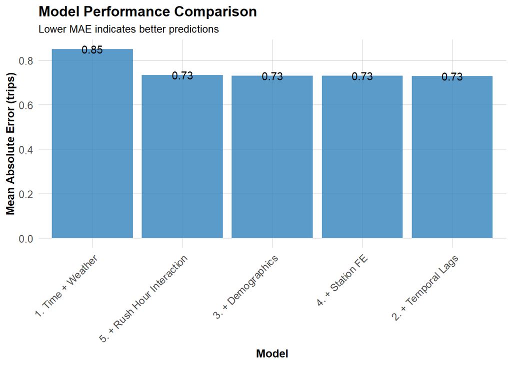

```r
ggplot(mae_results, aes(x = reorder(Model, -MAE), y = MAE)) +
  geom_col(fill = "#3182bd", alpha = 0.8) +
  geom_text(aes(label = round(MAE, 2))) +
  labs(
    title = "Model Performance Comparison",
    subtitle = "Lower MAE indicates better predictions",
    x = "Model",
    y = "Mean Absolute Error (trips)"
  ) +
  plotTheme +
  theme(axis.text.x = element_text(angle = 45, hjust = 1))
```

The biggest improvement comes from adding the temporal lag variables. The drop in MAE from Model 1 to Model 2 is much larger than any changes that come after, while demographics, station fixed effects, and interaction terms barely move the needle. Most of the predictive power is coming from recent past demand rather than the additional features.

# SPACE-TIME ERROR ANALYSIS

## Observed vs. Predicted

Let’s use our best model (Model 2) for error analysis.

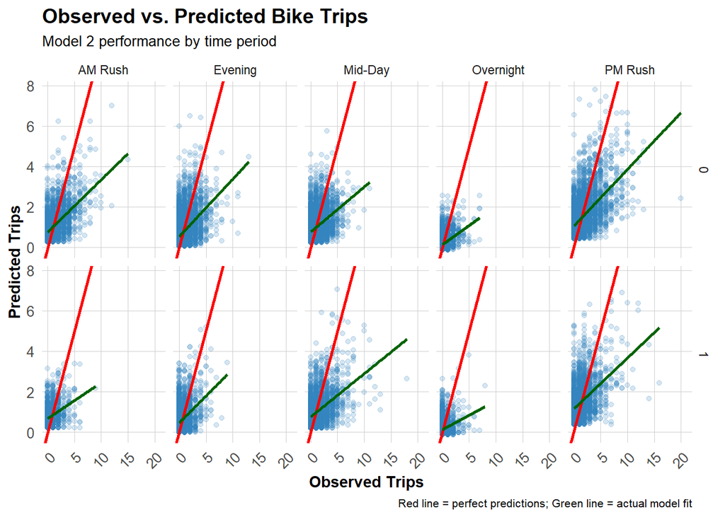

```r
test <- test %>%
  mutate(
    error = Trip_Count - pred2,
    abs_error = abs(error),
    time_of_day = case_when(
      hour < 7 ~ "Overnight",
      hour >= 7 & hour < 10 ~ "AM Rush",
      hour >= 10 & hour < 15 ~ "Mid-Day",
      hour >= 15 & hour <= 18 ~ "PM Rush",
      hour > 18 ~ "Evening"
    )
  )

# Scatter plot by time and day type
ggplot(test, aes(x = Trip_Count, y = pred2)) +
  geom_point(alpha = 0.2, color = "#3182bd") +
  geom_abline(slope = 1, intercept = 0, color = "red", linewidth = 1) +
  geom_smooth(method = "lm", se = FALSE, color = "darkgreen") +
  facet_grid(weekend ~ time_of_day) +
  labs(
    title = "Observed vs. Predicted Bike Trips",
    subtitle = "Model 2 performance by time period",
    x = "Observed Trips",
    y = "Predicted Trips",
    caption = "Red line = perfect predictions; Green line = actual model fit"
  ) +
  plotTheme
```

The model performs best at low to moderate trip levels, where most of the points are more tightly clustered around the fitted line. This is especially noticeable during overnight and mid-day periods, when demand is lower and more stable.

It struggles more during peak periods, particularly during the PM rush, where observed trip counts get much higher. In these cases, the model tends to underpredict, as shown by the points falling below the red line. The spread of points is also wider during these periods, indicating more variability that the model isn’t fully capturing.

## Spatial Error Patterns

Are prediction errors clustered in certain parts of Philadelphia?

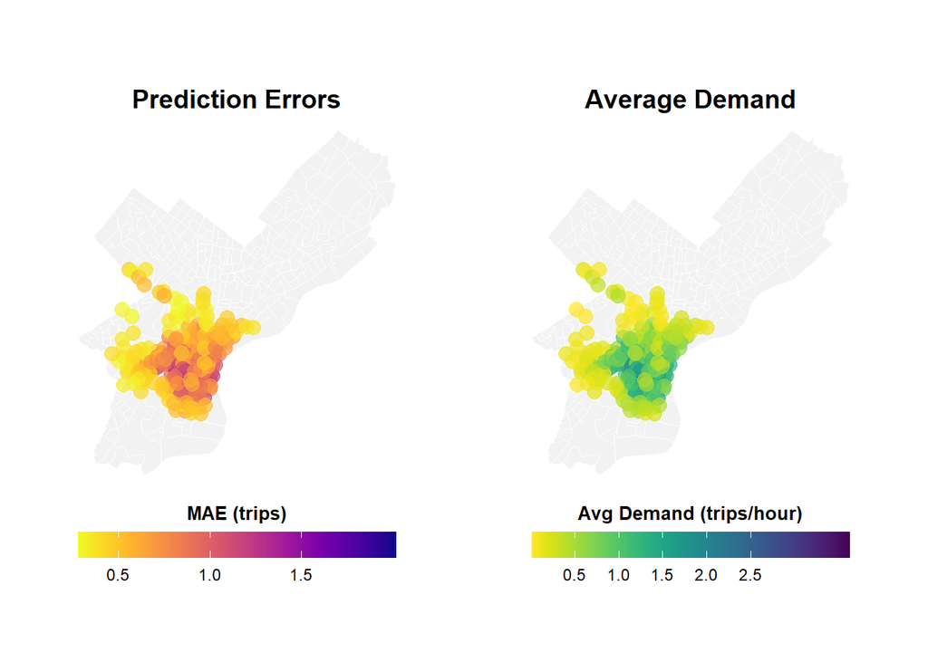

```r
# Calculate MAE by station
station_errors <- test %>%
  group_by(start_station, start_lat, start_lon) %>%
  summarize(
    MAE = mean(abs_error, na.rm = TRUE),
    avg_demand = mean(Trip_Count, na.rm = TRUE),
    .groups = "drop"
  ) %>%
  filter(!is.na(start_lat), !is.na(start_lon))

## Create Two Maps Side-by-Side with Proper Legends

# Calculate station errors
station_errors <- test %>%
  filter(!is.na(pred2)) %>%
  group_by(start_station, start_lat, start_lon) %>%
  summarize(
    MAE = mean(abs(Trip_Count - pred2), na.rm = TRUE),
    avg_demand = mean(Trip_Count, na.rm = TRUE),
    .groups = "drop"
  ) %>%
  filter(!is.na(start_lat), !is.na(start_lon))

# Map 1: Prediction Errors
p1 <- ggplot() +
  geom_sf(data = philly_census, fill = "grey95", color = "white", size = 0.1) +
  geom_point(
    data = station_errors,
    aes(x = start_lon, y = start_lat, color = MAE),
    size = 3.5,
    alpha = 0.7
  ) +
  scale_color_viridis(
    option = "plasma",
    name = "MAE (trips)",
    direction = -1,
    breaks = c(0.5, 1.0, 1.5),
    labels = c("0.5", "1.0", "1.5")
  ) +
  labs(title = "Prediction Errors") +
  mapTheme +
  theme(
    legend.position = "bottom",
    legend.title = element_text(size = 10, face = "bold"),
    legend.text = element_text(size = 9),
    plot.title = element_text(size = 14, face = "bold", hjust = 0.5)
  ) +
  guides(color = guide_colorbar(
    barwidth = 12,
    barheight = 1,
    title.position = "top",
    title.hjust = 0.5
  ))

# Map 2: Average Demand
p2 <- ggplot() +
  geom_sf(data = philly_census, fill = "grey95", color = "white", size = 0.1) +
  geom_point(
    data = station_errors,
    aes(x = start_lon, y = start_lat, color = avg_demand),
    size = 3.5,
    alpha = 0.7
  ) +
  scale_color_viridis(
    option = "viridis",
    name = "Avg Demand (trips/hour)",
    direction = -1,
    breaks = c(0.5, 1.0, 1.5, 2.0, 2.5),
    labels = c("0.5", "1.0", "1.5", "2.0", "2.5")
  ) +
  labs(title = "Average Demand") +
  mapTheme +
  theme(
    legend.position = "bottom",
    legend.title = element_text(size = 10, face = "bold"),
    legend.text = element_text(size = 9),
    plot.title = element_text(size = 14, face = "bold", hjust = 0.5)
  ) +
  guides(color = guide_colorbar(
    barwidth = 12,
    barheight = 1,
    title.position = "top",
    title.hjust = 0.5
  ))

# Combine
(p1 | p2)
```

There is clear spatial clustering of errors. Higher prediction errors are concentrated in and around Center City and nearby high-demand areas, where ridership is also the highest. These central neighborhoods show more variability, which makes them harder for the model to predict accurately.

In contrast, stations farther from the core tend to have lower errors, likely because demand is lower and more consistent.

## Temporal Error Patterns

When are we most wrong?

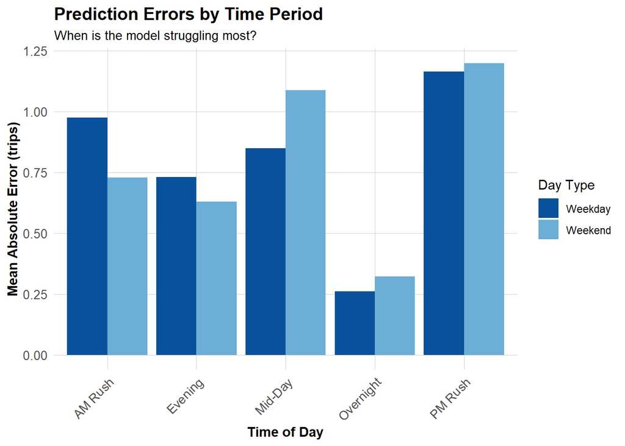

```r
# MAE by time of day and day type
temporal_errors <- test %>%
  group_by(time_of_day, weekend) %>%
  summarize(
    MAE = mean(abs_error, na.rm = TRUE),
    .groups = "drop"
  ) %>%
  mutate(day_type = ifelse(weekend == 1, "Weekend", "Weekday"))

ggplot(temporal_errors, aes(x = time_of_day, y = MAE, fill = day_type)) +
  geom_col(position = "dodge") +
  scale_fill_manual(values = c("Weekday" = "#08519c", "Weekend" = "#6baed6")) +
  labs(
    title = "Prediction Errors by Time Period",
    subtitle = "When is the model struggling most?",
    x = "Time of Day",
    y = "Mean Absolute Error (trips)",
    fill = "Day Type"
  ) +
  plotTheme +
  theme(axis.text.x = element_text(angle = 45, hjust = 1))
```

The model is most wrong during the PM rush, where errors are the highest for both weekdays and weekends. Errors are also relatively high during mid-day, especially on weekends.

On the other side, the model performs best overnight when demand is low and more stable. This pattern lines up with earlier results—when ridership is higher and more variable, the model has a harder time predicting it accurately.

## Errors and Demographics

Are prediction errors related to neighborhood characteristics?

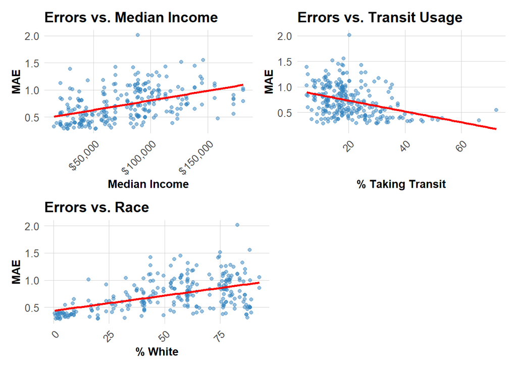

```r
# Join demographic data to station errors
station_errors_demo <- station_errors %>%
  left_join(
    station_attributes %>% select(start_station, Med_Inc, Percent_Taking_Transit, Percent_White),
    by = "start_station"
  ) %>%
  filter(!is.na(Med_Inc))

# Create plots
p1 <- ggplot(station_errors_demo, aes(x = Med_Inc, y = MAE)) +
  geom_point(alpha = 0.5, color = "#3182bd") +
  geom_smooth(method = "lm", se = FALSE, color = "red") +
  scale_x_continuous(labels = scales::dollar) +
  labs(title = "Errors vs. Median Income", x = "Median Income", y = "MAE") +
  plotTheme

p2 <- ggplot(station_errors_demo, aes(x = Percent_Taking_Transit, y = MAE)) +
  geom_point(alpha = 0.5, color = "#3182bd") +
  geom_smooth(method = "lm", se = FALSE, color = "red") +
  labs(title = "Errors vs. Transit Usage", x = "% Taking Transit", y = "MAE") +
  plotTheme

p3 <- ggplot(station_errors_demo, aes(x = Percent_White, y = MAE)) +
  geom_point(alpha = 0.5, color = "#3182bd") +
  geom_smooth(method = "lm", se = FALSE, color = "red") +
  labs(title = "Errors vs. Race", x = "% White", y = "MAE") +
  plotTheme

(p1 | p2) / (p3 | plot_spacer())
```

There are some noticeable patterns in how errors relate to demographics. Errors tend to be slightly higher in higher-income areas and in neighborhoods with a higher percentage of white residents, while errors decrease as the share of people taking transit increases. These relationships are not extremely strong, but they are consistent enough to suggest that the model performs differently across neighborhoods.

From an equity perspective, this matters because uneven prediction accuracy could translate into uneven service. If the model is less accurate in certain types of neighborhoods—especially those with different travel behaviors or land use patterns—it could lead to worse bike availability or rebalancing decisions in those areas. Even small systematic differences in error can compound over time, potentially reinforcing existing disparities in access to bike share.

# FEATURE ENGINEERING AND MODEL IMPROVEMENT

Next, I will add 2 new features to improve my model.

## Feature 1: Same Hour Last Week

Because the lag variables improved the model the most, I decided to add another temporal demand feature: the same hour last week. This helps capture weekly travel routines that a 1-hour or 1-day lag may miss. For example, demand at 8 AM on a Tuesday is probably more similar to 8 AM on the previous Tuesday than to some other recent hour.

## Feature 2: School-in-Session Indicator

I also added a school-in-session indicator because Q3 includes the transition from summer into the fall semester. In a city like Philadelphia, universities likely shape bike share demand, especially near Penn, Drexel, and Temple. This feature helps the model account for the seasonal return of students and campus activity.

## Creat New Features

```r
# Add two new features:
# 1. same hour last week
# 2. school in session

study_panel <- study_panel %>%
  arrange(start_station, interval60) %>%
  group_by(start_station) %>%
  mutate(
    lag1Hour = lag(Trip_Count, 1),
    lag3Hours = lag(Trip_Count, 3),
    lag1day = lag(Trip_Count, 24),
    same_hour_last_week = lag(Trip_Count, 168)
  ) %>%
  ungroup() %>%
  mutate(
    week = week(interval60),
    dotw = wday(interval60, label = TRUE, abbr = TRUE),
    hour = hour(interval60),
    date = as.Date(interval60),

    weekend = ifelse(dotw %in% c("Sat", "Sun"), 1, 0),

    # NEW FEATURE
    school_in_session = ifelse(date >= as.Date("2025-08-25"), 1, 0)
  )

# Remove NA rows AFTER all lags exist
study_panel_complete <- study_panel %>%
  filter(!is.na(lag1day), !is.na(same_hour_last_week))

train <- study_panel_complete %>%
  filter(week < 39)

test <- study_panel_complete %>%
  filter(week >= 39)
```

```r
train <- train %>%
  mutate(
    dotw_simple = factor(dotw,
      levels = c("Mon","Tue","Wed","Thu","Fri","Sat","Sun"))
  )

test <- test %>%
  mutate(
    dotw_simple = factor(dotw,
      levels = c("Mon","Tue","Wed","Thu","Fri","Sat","Sun"))
  )

contrasts(train$dotw_simple) <- contr.treatment(7)
contrasts(test$dotw_simple) <- contr.treatment(7)
```

## New Model

```r
model6 <- lm(
  Trip_Count ~ as.factor(hour) + dotw_simple + Temperature + Precipitation +
    lag1Hour + lag3Hours + lag1day +
    same_hour_last_week + school_in_session +
    Med_Inc + Percent_Taking_Transit + Percent_White +
    as.factor(start_station),
  data = train
)

summary(model6)
```

```
Call:
lm(formula = Trip_Count ~ as.factor(hour) + dotw_simple + Temperature +
    Precipitation + lag1Hour + lag3Hours + lag1day + same_hour_last_week +
    school_in_session + Med_Inc + Percent_Taking_Transit + Percent_White +
    as.factor(start_station), data = train)

Residuals:
    Min      1Q  Median      3Q     Max
-7.1538 -0.5164 -0.1222  0.2520 16.5974

Coefficients: (3 not defined because of singularities)
                                   Estimate     Std. Error t value
(Intercept)                   -3.4549923843   0.3720131782  -9.287
as.factor(hour)1              -0.0283308595   0.0105968819  -2.674
as.factor(hour)2              -0.0432931115   0.0106231024  -4.075
as.factor(hour)3              -0.0689322879   0.0106610830  -6.466
as.factor(hour)4              -0.0569778760   0.0107068006  -5.322
as.factor(hour)5               0.0296571226   0.0107223254   2.766
as.factor(hour)6               0.1657965662   0.0107758112  15.386
as.factor(hour)7               0.3231561729   0.0108185247  29.871
as.factor(hour)8               0.5400773401   0.0109350278  49.390
as.factor(hour)9               0.2675396706   0.0108925557  24.562
as.factor(hour)10              0.2242590938   0.0108353179  20.697
as.factor(hour)11              0.2661699023   0.0107662976  24.723
as.factor(hour)12              0.3247100871   0.0106828131  30.396
as.factor(hour)13              0.3469281886   0.0106585252  32.549
as.factor(hour)14              0.3848897726   0.0106911435  36.001
as.factor(hour)15              0.4457304304   0.0107661906  41.401
as.factor(hour)16              0.5872696754   0.0108927832  53.914
as.factor(hour)17              0.7585860318   0.0110769407  68.483
as.factor(hour)18              0.5120143995   0.0110778505  46.220
as.factor(hour)19              0.3671077393   0.0109956501  33.387
as.factor(hour)20              0.2049845325   0.0109535363  18.714
as.factor(hour)21              0.1494984550   0.0108037930  13.838
as.factor(hour)22              0.1097717498   0.0106902906  10.268
as.factor(hour)23              0.0630655411   0.0106069297   5.946
dotw_simple2                   0.0385971189   0.0056334769   6.851
dotw_simple3                  -0.0175881026   0.0057641306  -3.051
dotw_simple4                   0.0376465164   0.0057800595   6.513
dotw_simple5                   0.0261171354   0.0057662158   4.529
```

[output cut: 568 more lines]

```
as.factor(start_station)3431 0.000000000000000648 ***
as.factor(start_station)3434 < 0.0000000000000002 ***
as.factor(start_station)3435 < 0.0000000000000002 ***
as.factor(start_station)3436 0.000000152102694390 ***
as.factor(start_station)3437 0.000000000034713997 ***
as.factor(start_station)3438 0.000000000000023075 ***
as.factor(start_station)3439                   NA
as.factor(start_station)3440                   NA
as.factor(start_station)3441                   NA
---
Signif. codes:  0 '***' 0.001 '**' 0.01 '*' 0.05 '.' 0.1 ' ' 1

Residual standard error: 1.071 on 492037 degrees of freedom
Multiple R-squared:  0.4044,    Adjusted R-squared:  0.404
F-statistic:  1121 on 298 and 492037 DF,  p-value: < 0.00000000000000022
```

## Test and Evaluate Model

```r
# predict
test <- test %>%
  mutate(
    pred6 = predict(model6, newdata = test)
  )

# calculate MAE
mae_model6 <- mean(abs(test$Trip_Count - test$pred6), na.rm = TRUE)

mae_results <- bind_rows(
  mae_results,
  tibble(
    Model = "6. + Same Hour Last Week + School",
    MAE = mae_model6
  )
)

kable(
  mae_results %>% mutate(MAE = round(MAE, 3)),
  caption = "Mean Absolute Error by Model (Test Set)"
) %>%
  kable_styling(bootstrap_options = c("striped", "hover"))
```

Mean Absolute Error by Model (Test Set)

| Model | MAE |
| --- | --- |
| 1. Time + Weather | 0.850 |
| 2. + Temporal Lags | 0.728 |
| 3. + Demographics | 0.731 |
| 4. + Station FE | 0.730 |
| 5. + Rush Hour Interaction | 0.734 |
| 6. + Same Hour Last Week + School | 0.706 |

Adding these features reduced MAE from 0.728 to 0.706, which is a noticeable improvement compared to the very small changes from earlier feature additions. This suggests that incorporating additional temporal structure, especially weekly demand patterns, provides meaningful gains in predictive accuracy.

These features likely improved predictions during more structured demand periods, such as weekday commuting hours and the late-Q3 period when students return. The same hour last week variable helps stabilize predictions by capturing recurring weekly patterns, while the school indicator helps account for broader seasonal shifts in ridership.

# REFLECTION

The final MAE of approximately 0.71 trips per station-hour suggests that the model performs reasonably well, especially given that most station-hours have very low demand. On average, the model is off by less than one trip, which may be acceptable for general system planning. However, errors become more problematic during peak demand periods, particularly during the PM rush, when underprediction could lead to empty stations or insufficient bike availability. I would recommend deploying this model as a baseline decision-support tool rather than a fully automated system. It could be useful for identifying general rebalancing patterns and prioritizing high-demand stations, but operators should still rely on real-time monitoring during peak periods when prediction errors are larger and more consequential.

There is some evidence that prediction errors vary across neighborhoods, with slightly higher errors in higher-demand, central areas. While these areas may be better served overall, uneven prediction accuracy could still lead to inconsistent service quality. If the model performs worse in certain neighborhoods, it could result in less reliable bike availability, which may disproportionately affect users who rely on bike share for commuting. To avoid reinforcing disparities, safeguards should include monitoring prediction errors across neighborhoods and ensuring minimum service levels regardless of predicted demand. Incorporating equity constraints into rebalancing decisions could help ensure that lower-demand or historically underserved areas are not deprioritized.

The model still struggles to capture high-demand spikes, particularly during peak commuting periods and unusual events. This suggests that important drivers of demand, such as special events, real-time weather conditions, and network connectivity, are not fully captured. Additionally, the model assumes that past demand patterns will continue, which may not hold during sudden disruptions or long-term changes in travel behavior.With more time and data, the model could be improved by incorporating richer spatial features, such as proximity to points of interest or bike lane infrastructure, as well as more detailed temporal variables like rolling averages or event indicators. More advanced modeling approaches, such as machine learning methods, could also help capture nonlinear relationships and improve performance.